# The `shipstrike` encounter rate simulator

Eric Keen

February 2022

This vignette demonstrates the utilities within the `R` package `shipstrike` by stepping through the analysis for Keen et al., “A simulation-based tool for predicting whale-vessel encounter rates” (submitted to *Ocean & Coastal Management*). This study is carried out in close collaboration with the Gitga’at First Nation, North Coast Cetacean Society, and WWF-Canada as part of a research project named **SWAG**: *Ships, Whales, and Acoustics in Gitga’at waters*.

## Setup

**1. Start a new script** in `RStudio` and save it within this directory’s `R` folder.

**2. Load libraries** at the top of your script. Install the packages you don’t yet have.

```r
library(rstudioapi)
library(devtools)
library(dplyr)
library(lubridate)
library(graphics)
library(truncnorm)
library(solartime)
library(boot)
library(DescTools)
library(sf)
library(leaflet)
library(bangarang)
library(knitr)
library(ggplot2)
library(ggpubr)
```

**3. Install the `shipstrike` package**.

```r
document('../../shipstrike/')
```

```
#> ℹ Updating shipstrike documentation
#> ℹ Loading shipstrike
#> Writing NAMESPACE
#> Writing NAMESPACE
```

```r
load_all('../../shipstrike/')
```

```
#> ℹ Loading shipstrike
```

## Marine traffic data

### Formatting archival AIS data

Subsequent steps will require AIS data to be formatted into a `data.frame` meeting the following criteria:

- Each row contains details for a single vessel.
- There is a column named `vid`, containing a unique identifier for each vessel (e.g., MMSI).
- There is a column named `type`, containing the category or class of vessel.
- There is a column named `speed`, containing speed-over-ground in knots.
- There is a column named `length`, containing vessel length in meters.
- There is a column named `width`, containing vessel beam width in meters.
- There is a column named `draft`, containing vessel draft at this timestamp.
- There is a column named `datetime`, with date/time, in UTC, formatted as `yyyy-mm-dd hh:mm:ss`.
- There are columns named `x` and `y` for longitude and latitude, respectively, in decimal degrees.

#### Example script

Here is the code we used to format the raw AIS data provided to us by the Canadian Coast Guard. You may use this dataset to familiarize yourself with the simulator.

First, load the raw AIS data (all AIS records for central Gitga’at waters from July 1 to October 31, 2018):

```r
data(ais, package='shipstrike')
```

Check out the AIS data in its raw form:

```r
nrow(ais)
```

```
#> [1] 259727
```

```r
head(ais)
```

```
#>    rowid      Local.Time Year month day     time ampm   ID           Type
#> 1 448787 2018-07-01 0:00 2018     7   1 12:00:00   AM 1303            Tug
#> 2 448788 2018-07-01 0:00 2018     7   1 12:00:00   AM 2079        Fishing
#> 3 448789 2018-07-01 0:00 2018     7   1 12:00:00   AM  417        Fishing
#> 4 448790 2018-07-01 0:01 2018     7   1 12:01:00   AM  417        Fishing
#> 5 448791 2018-07-01 0:02 2018     7   1 12:02:00   AM  417        Fishing
#> 6 448792 2018-07-01 0:02 2018     7   1 12:02:00   AM 1938 Pleasure Craft
#>   Length  SOG   COG Latitude Longitude
#> 1     22  6.9 144.0 53.14665 -128.6124
#> 2     38 12.2 318.6 53.56710 -129.6501
#> 3     22  0.0 310.3 52.59444 -128.5214
#> 4     22  0.0 337.0 52.59446 -128.5213
#> 5     22  0.0 307.4 52.59446 -128.5214
#> 6     22  0.1 165.2 52.57265 -128.5153
```

```r
ais <- ais %>% dplyr::filter(SOG > 3, # speed is provided in knots
                             SOG < 40,
                             Length > 5,
                             Length < 500)
nrow(ais)
```

```
#> [1] 147639
```

Explore the data as a map, including the prime fin whale habitat within Gitga’at First Nation waters:

```r
# Plot the Kitimat Fjord System
bangarang::plotKFS()
```

[output not shown]

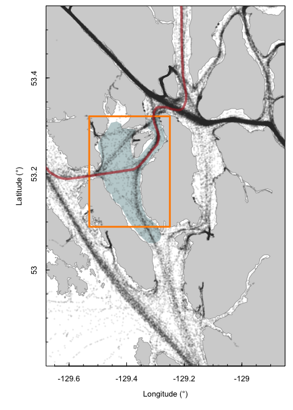

```r
# Plot waterway with highest fin whale density
data(fin_whale_habitat, package='shipstrike')
polygon(x=fin_whale_habitat$x,
        y=fin_whale_habitat$y,
        col=adjustcolor('cadetblue4',alpha.f=.4),
        border=NA)

# Plot AIS traffic
points(x=ais$Longitude, y=ais$Latitude,
       cex=.4, pch=16, col=adjustcolor('grey20',alpha.f=.1))
graphics::rect(xleft = -129.53, ybottom = 53.09, xright = -129.25, ytop=53.32,
               border='darkorange', lwd=3)

# Plot proposed LNG traffic route
data(tanker_route, package='shipstrike')
lines(tanker_route, col=adjustcolor('firebrick',alpha.f=.6), lwd=4)
```

Filter to our study area:

```r
ais <- ais %>% dplyr::filter(Longitude >= -129.53,
                             Longitude < -129.25,
                             Latitude >= 53.09,
                             Latitude < 53.32)
```

Now format these data to meet the requirements stipulated above:

```r
# Format as local time first
dt <-
  paste0(ais$Local.Time,':00') %>%
  lubridate::as_datetime(tz='Canada/Pacific')

# Correct for AM/PM
dt[ais$ampm == 'PM'] <- dt[ais$ampm == 'PM'] + lubridate::hours(12)

# Translate to UTC
dt <- dt %>% lubridate::as_datetime(tz='UTC')

# Now re-format `ais`
ais <- data.frame(vid = ais$ID,
                  type = ais$Type,
                  speed = (ais$SOG),
                  length = ais$Length,
                  width = NA,
                  draft = NA,
                  datetime = dt,
                  x = ais$Longitude,
                  y = ais$Latitude)

# Review revised AIS:
head(ais)
```

```
#>   vid           type speed length width draft            datetime         x
#> 1 691 Pleasure Craft   3.2     25    NA    NA 2018-07-01 16:34:00 -129.5181
#> 2 691 Pleasure Craft   6.9     25    NA    NA 2018-07-01 16:36:00 -129.5200
#> 3 691 Pleasure Craft   7.9     25    NA    NA 2018-07-01 16:38:00 -129.5178
#> 4 691 Pleasure Craft   8.9     25    NA    NA 2018-07-01 16:42:00 -129.5122
#> 5 691 Pleasure Craft   8.7     25    NA    NA 2018-07-01 16:44:00 -129.5117
#> 6 691 Pleasure Craft   8.5     25    NA    NA 2018-07-01 16:46:00 -129.5104
#>          y
#> 1 53.30738
#> 2 53.30514
#> 3 53.30122
#> 4 53.29251
#> 5 53.28745
#> 6 53.28289
```

Since these AIS data do not provide width or draft, let’s approximate them by scaling vessel length:

```r
# Beam width
ais$width <- ais$length * (1/8)
# middle road beween 6:1 and 10:1
# http://marine.marsh-design.com/content/length-beam-ratio

# Draft
ais$draft <- ais$length * 0.05
# https://transportgeography.org/contents/chapter5/maritime-transportation/draft-containership-capacity/
```

Finally, let’s establish a difference between small (<= 100m) and large (> 100m) passenger ships:

```r
ais$type[ ais$type == 'Passenger ship' & ais$length <= 100 ] <- 'Passenger small'
```

### Summarizing AIS data

Now let’s see the various vessel types included in this data:

```r
# Unique location fixes
nrow(ais)
```

```
#> [1] 4637
```

```r
# Unique vessels
ais$vid %>% unique %>% length
```

```
#> [1] 130
```

```r
# Records of each type
ais$type %>% table
```

```
#> .
#> Anti-pollution facil./equip.                   Cargo ship
#>                           15                           25
#>                      Fishing                        Other
#>                          375                           32
#>               Passenger ship              Passenger small
#>                          576                          284
#>               Pleasure Craft                      Sailing
#>                         1676                          473
#>                Search/rescue                       Towing
#>                          291                           44
#>               Towing(200/25)                          Tug
#>                          496                          350
```

Summarize each vessel class:

```r
ais_table <-
  ais %>%
  group_by(type) %>%
  summarize(vids = unique(vid) %>% length,
            fixes = n(),
            dates = lubridate::yday(datetime) %>% unique %>% length,
            transits_per_day = dates / 122,
            speed_mean = mean(speed, na.rm=TRUE),
            speed_sd = sd(speed, na.rm=TRUE),
            speed_max = max(speed, na.rm=TRUE),
            length_mean = mean(length, na.rm=TRUE),
            length_sd = sd(length, na.rm=TRUE),
            length_min = min(length, na.rm=TRUE),
            length_max = max(length, na.rm=TRUE))

knitr::kable(ais_table)
```

| type | vids | fixes | dates | transits_per_day | speed_mean | speed_sd | speed_max | length_mean | length_sd | length_min | length_max |
| --- | --- | --- | --- | --- | --- | --- | --- | --- | --- | --- | --- |
| Anti-pollution facil./equip. | 1 | 15 | 1 | 0.0081967 | 18.326667 | 0.2789436 | 18.7 | 15.00000 | 0.000000 | 15 | 15 |
| Cargo ship | 1 | 25 | 1 | 0.0081967 | 13.180000 | 0.2236068 | 13.6 | 190.00000 | 0.000000 | 190 | 190 |
| Fishing | 10 | 375 | 14 | 0.1147541 | 7.258933 | 1.9170412 | 11.6 | 21.04533 | 8.955061 | 10 | 36 |
| Other | 2 | 32 | 2 | 0.0163934 | 10.918750 | 1.3977949 | 13.1 | 43.50000 | 14.732015 | 29 | 58 |
| Passenger ship | 7 | 576 | 35 | 0.2868852 | 17.232639 | 2.1781150 | 21.3 | 259.03819 | 48.294372 | 116 | 301 |
| Passenger small | 6 | 284 | 11 | 0.0901639 | 7.176761 | 1.9543434 | 10.8 | 27.02113 | 7.142634 | 19 | 50 |
| Pleasure Craft | 65 | 1676 | 59 | 0.4836066 | 7.481265 | 2.5480261 | 28.2 | 17.48508 | 7.879034 | 7 | 46 |
| Sailing | 14 | 473 | 19 | 0.1557377 | 5.904440 | 1.1579869 | 8.7 | 14.85624 | 5.577312 | 9 | 32 |
| Search/rescue | 2 | 291 | 18 | 0.1475410 | 9.479038 | 2.4403661 | 14.4 | 52.26804 | 2.493504 | 50 | 55 |
| Towing | 2 | 44 | 2 | 0.0163934 | 7.340909 | 1.5667057 | 9.9 | 29.88636 | 4.509504 | 26 | 35 |
| Towing(200/25) | 9 | 496 | 23 | 0.1885246 | 9.154839 | 1.5416955 | 12.3 | 34.26613 | 3.709902 | 25 | 40 |
| Tug | 11 | 350 | 18 | 0.1475410 | 7.165429 | 1.6305919 | 10.0 | 31.84571 | 36.391758 | 12 | 178 |

Let’s filter the data to vessel types of interest to us in this demo:

```r
ais <-
  ais %>%
  dplyr::filter(type %in% c('Tanker', 'Cargo ship', 'Passenger ship'))

nrow(ais) # unique fixes
```

```
#> [1] 601
```

```r
ais$vid %>% unique %>% length # unique vessels
```

```
#> [1] 8
```

### Summarizing marine traffic as a spatial grid

The next step is to summarize spatial patterns in vessel traffic. To do so, you need to supply a `data.frame` of information for a spatial grid. We already have a 1-square-km spatial grid prepared for Gitga’at First Nation waters:

```r
data(grid_kfs, package='shipstrike')

grid_kfs %>% head
```

```
#>         y1      y2        y        x1        x2         x      km2  id
#> 1 52.79656 52.8082 52.80238 -129.3193 -129.3077 -129.3135 1.016831 466
#> 2 52.79656 52.8082 52.80238 -129.3077 -129.2961 -129.3019 1.016831 467
#> 3 52.79656 52.8082 52.80238 -129.2146 -129.2029 -129.2088 1.016831 475
#> 4 52.79656 52.8082 52.80238 -129.2029 -129.1913 -129.1971 1.016831 476
#> 5 52.79656 52.8082 52.80238 -129.1913 -129.1797 -129.1855 1.016831 477
#> 6 52.79656 52.8082 52.80238 -129.1797 -129.1680 -129.1738 1.016831 478
#>           z       zmin     zmax       zsd    zrange block
#> 1 163.81329  0.0000005 209.7133 59.861445 209.71330   CAA
#> 2 223.28670 12.4876499 237.9200 44.017913 225.43235   CAA
#> 3  44.95333  0.0000000  79.5200 21.548575  79.52000   CAA
#> 4  68.68333 45.8133316  84.8300  6.757624  39.01667   CAA
#> 5  77.22667 69.2300034  95.6100  6.129383  26.38000   CAA
#> 6  97.62000 81.7600021 125.8667 11.170772  44.10670   CAA
```

Your spatial grid must have the columns `x1` (left longitudinal boundary, decimal degrees), `x2` (right longitudinal boundary), `x` (the longitudinal center of the grid cell), `y1` (bottom latitudinal boundary), `y2` (top latitudinal boundary), and `y` (the latitudinal center of the grid cell).

Here is what our grid looks like mapped onto the geography:

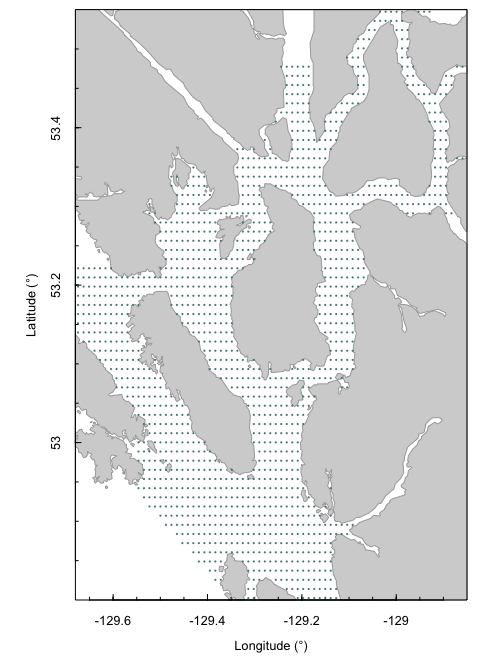

```r
bangarang::plotKFS()
points(x=grid_kfs$x, y=grid_kfs$y, cex=.3, pch=16, col='cadetblue4')
```

Next, we interpolate vessel position fixes and associate each interpolated fix to a grid cell, using a function from `shipstrike`. In the result, each row is an interpolated vessel position fix.

```r
vgrid <- vessel_grid(grid_kfs, ais, verbose=FALSE)
vgrid %>% head
```

```
#> # A tibble: 6 × 14
#> # Groups:   grid_id [5]
#>   grid_id   vid type    speed length width draft datetime                x     y
#>     <int> <int> <chr>   <dbl>  <int> <dbl> <dbl> <dttm>              <dbl> <dbl>
#> 1    3351   184 Passen…  20.1    285  35.6  14.2 2018-07-03 11:25:40 -129.  53.1
#> 2    3245   184 Passen…  20.1    285  35.6  14.2 2018-07-03 11:26:30 -129.  53.1
#> 3    3458   184 Passen…  20.1    285  35.6  14.2 2018-07-03 11:29:00 -129.  53.1
#> 4    3565   184 Passen…  20.1    285  35.6  14.2 2018-07-03 11:31:00 -129.  53.1
#> 5    3565   184 Passen…  20      285  35.6  14.2 2018-07-03 11:31:00 -129.  53.1
#> 6    3672   184 Passen…  20      285  35.6  14.2 2018-07-03 11:33:40 -129.  53.1
#> # … with 4 more variables: km <dbl>, year <dbl>, month <dbl>, yday <dbl>
```

Now add columns for the elevation of the sun during each record, using a function from the `shipstrike` package:

```r
vgrid$sun <- vessel_sun_angle(vgrid, verbose=FALSE)
```

We can then use solar elevation to determine which events occur during day (`sun` >= 0) and which during night (`sun` < 0). Note that some studies have used civil twilight or other metrics to draw this distinction. Here we are just keeping things simple.

```r
vgrid$diel <- 'day'
vgrid$diel[ais$sun < 0] <- 'night'
```

## Simulating additional traffic

To **simulate additional traffic** on top of the traffic already present, you can add rows to `params.ship`. This code emulates the traffic increase expected in 2030 in Gitga’at waters:

```r
data(tanker_route, package='shipstrike')
```

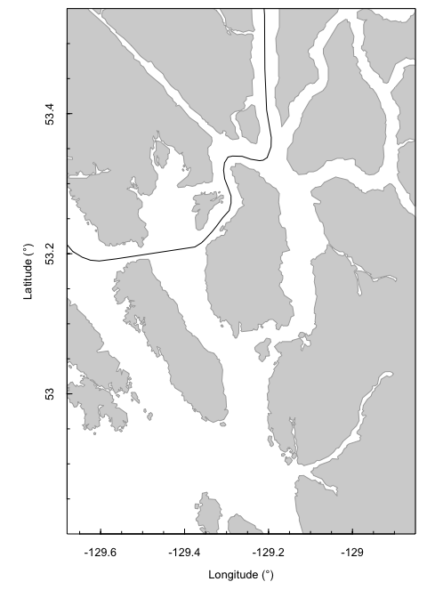

```r
par(mfrow=c(1,1))
plotKFS()
lines(tanker_route)
```

```r
# Number of transits expected July 1 - Oct 31, 2030 (4 months)
# based on 750 new tankers (1500 transits per year)
(new_transits <- 1500 * (4/12))
```

```
#> [1] 500
```

```r
# Prepare details for simulating tanker traffic
tankers <- list(type='tanker',
               n=new_transits,
               size_min = 270,
               size_max = 315,
               speed_min = 8,
               speed_max = 14,
               width = 0.15, # beam / length
               draft = 0.05, # draft / length
               course_var = .002, # add v. minor course variability
               course = tanker_route)
```

Simulate the AIS data for these tankers, using a function from `shipstrike`:

```r
vessels <- simulate_vessel(grids,
                           vessels=list(tankers),
                           toplot=FALSE,
                           verbose=FALSE)
```

As above, interpolate these fake AIS fixes and associate each fix with a grid cell ID (note that this step can be time consuming if you have many AIS fixes or a spatial grid with thousands of cells):

```r
vgrid_sim <- vessel_grid(grid_kfs, vessels, verbose=FALSE)
```

Determine the sun angle for each fake AIS fix:

```r
vgrid_sim$sun <- vessel_sun_angle(vgrid_sim, verbose=FALSE)
```

Based on sun angle, assign a diel period designation (night or day):

```r
vgrid_sim$diel <- 'night'
vgrid_sim$diel[vgrid_sim$sun > 0] <- 'day'
```

Finally, crop the grid to the same bounding box as that we used for the empirical AIS data:

```r
vgrid_sim <-
  vgrid_sim %>% dplyr::filter(x >= -129.53,
                            x < -129.25,
                            y >= 53.09,
                            y < 53.32)
```

### Final formatting steps

Finally, let’s set up the three vessel datasets we will be comparaing: passenger vessels > 100 m in 2018, cargo ships in 2018, and tankers in 2030:

```r
passenger <- vgrid %>% dplyr::filter(tolower(type) == 'passenger ship')
nrow(passenger)
```

```
#> [1] 1250
```

```r
cargo <- vgrid %>% dplyr::filter(tolower(type) == 'cargo ship')
nrow(cargo)
```

```
#> [1] 46
```

```r
tanker <- vgrid_sim
nrow(tanker)
```

```
#> [1] 14375
```

… and summarize the vessel activity in each grid cell. Note that, for the remainder of this demo, we will focus only on the `tanker` data:

```r
tanker_grid <- summarize_grid(tanker)$grid
```

In this result, each row corresponds to a single spatial grid cell, and the columns `speed`, `length`, `width`, and `draft` record the metrics for each vessel that enters the cell, with the metrics for each transit separated by an underscore, `_`. The column `n` indicates the number of transits that intersected the grid cell.

```r
tanker_grid %>% head
```

```
#> # A tibble: 6 × 11
#> # Groups:   type, month, diel [1]
#>   type   month diel  grid_id     x     y     n speed          length width draft
#>   <chr>  <dbl> <chr>   <int> <dbl> <dbl> <int> <chr>          <chr>  <chr> <chr>
#> 1 tanker     1 day      4086 -130.  53.2    11 8.9_9.1_13.9_… 293.6… 44_4… 14.7…
#> 2 tanker     1 day      4087 -130.  53.2    12 10.1_8.9_9.1_… 281.7… 42.3… 14.1…
#> 3 tanker     1 day      4088 -130.  53.2    12 10.1_8.9_9.1_… 281.7… 42.3… 14.1…
#> 4 tanker     1 day      4089 -129.  53.2    11 10.1_8.9_13.9… 281.7… 42.3… 14.1…
#> 5 tanker     1 day      4090 -129.  53.2    11 10.1_8.9_13.9… 281.7… 42.3… 14.1…
#> 6 tanker     1 day      4091 -129.  53.2     9 10.1_13.9_10.… 281.7… 42.3… 14.1…
```

Also note that this is the point at which you decide to conduct a temporally explicit analysis or not. If yes, you would conduct a separate encounter rate simulation for each month and diel period. If not, you can pool all months and diel periods together. For the sake of this simplified demonstration, we are going to opt for the latter: months and diel periods will be pooled.

To translate this summary dataframe into a distribution of vessel parameters that is appropriately weighted by the spatial prevalence of certain values, we can use another `data.frame` returned by `summarize_grid()`:

```r
params.ship <- summarize_grid(tanker)$params.ship
```

That routine produces a simple dataframe in which each row represents metrics (speed, length, and width) for each square kilometer grid cell intersected by each ship on each transit of the area. The dataframe represents a spatially weighted distribution of the ship metrics that may be encountered during the time period in question.

```r
nrow(params.ship)
```

```
#> [1] 14375
```

```r
head(params.ship)
```

```
#>   v.ship l.ship w.ship
#> 1    8.9  293.6   44.0
#> 2    9.1  296.5   44.5
#> 3   13.9  282.5   42.4
#> 4   10.9  302.0   45.3
#> 5   12.0  308.3   46.2
#> 6   11.9  290.6   43.6
```

## Whales

The parameters that characterize a whale in the encounter simulator can be defined as either a single value (e.g., 20 meters), or as a distribution of values from which to draw random values. In this example, we will do the latter.

Define the size of the distributions you will use:

```r
n <- 1000
```

These distributions will be truncated-normal distributions, to ensure that no value is unrealistically small or large.

### Whale velocity

Whale velocity should be provided as meters per second. We draw values from the acoustic tracks of fin whales from the same study area in Hendricks et al. (2021).

```r
v.whale = truncnorm::rtruncnorm(n,
                                a=0,
                                b=2.63,
                                mean=1.3611,
                                sd=.5)
```

### Whale directivity

Whale directivity, which we define in our paper as the standard deviation of change in course heading from one minute to the next, is also drawn from Hendricks et al. (2021). In that paper, 62 acoustic tracks of at least 30 minutes duration were analyzed. Refer to `prep_delta_sd.R` for details on how this was determined. Note that, in this analysis, the standard deviation of course changes were log-transformed so that they followed a Gaussian distribution.

```r
# Produce distribution of log-transformed values
delta.sd = rnorm(n,
                 mean = 1.0424,
                 sd = 0.82477)

# Revert from log-transformed to actual SD of course change
delta.sd <- exp(delta.sd)
```

### Whale dimensions

Whale length is drawn from UAV-based photogrammetry measurements for fin whales in our study area, published in Keen et al. (2021).

```r
l.whale = truncnorm::rtruncnorm(n = n,  # samples
                                a = 0,  # min
                                b = 40, # max
                                mean = 18.60375,
                                sd = 1.649138)
```

To estimate whale widths, we use the ratio of fluke width to body length from Keen et al. (2021).

```r
w.whale = .2074
```

Visualize the distributions of these parameters:

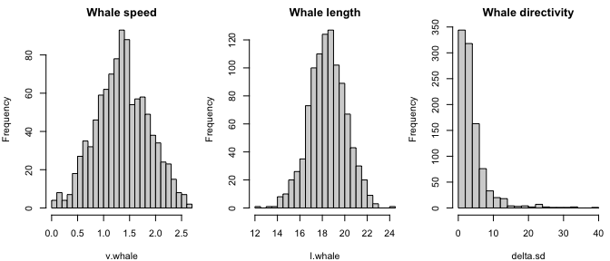

```r
par(mfrow=c(1,3))
par(mar=c(4,4,2,.5))
hist(v.whale,breaks=20,main='Whale speed')
hist(l.whale,breaks=20,main='Whale length')
hist(delta.sd,breaks=20,main='Whale directivity')
```

## Encounter rate simulator

### Basic example

You can conduct an encounter rate simulation using the `shipstrike` function. The code below demonstrates differences in various whale directivity values:

```r
par(mfrow=c(1,3))
delta.sds <- c(0,30,80)

for(i in 1:3){
encounters <-
  encounter_simulator(params.ship=params.ship,
                      v.whale=v.whale,
                      l.whale=l.whale,
                      w.whale=w.whale,
                      delta.sd=delta.sds[i],
                      B=100)
}
```

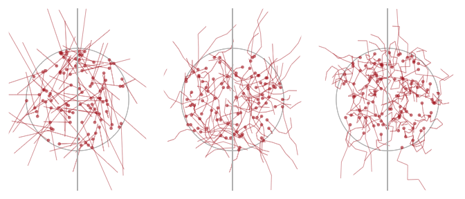

When you run this simulator, the result is a list with two slots:

```r
encounters %>% names
```

```
#> [1] "summary" "records"
```

The `summary` slot contains a summary of each simulator run:

```r
encounters$summary %>% head
```

```
#>   run encounter  closest whale_hdg   whale_x  whale_y   whale_v  whale_l
#> 1   1         0       NA        NA        NA       NA 1.1507323 18.99193
#> 2   2         0       NA        NA        NA       NA 0.1034079 19.92964
#> 3   3         0 6.776144   261.262 -19.92886 409.0772 1.3387654 20.16905
#> 4   4         0       NA        NA        NA       NA 0.9353499 20.37457
#> 5   5         0       NA        NA        NA       NA 1.2688162 17.45912
#> 6   6         0       NA        NA        NA       NA 1.1561716 20.35180
#>    whale_w whale_deltasd   ship_v ship_l ship_w       ship_x   ship_y
#> 1 3.938925            80 5.967504  289.5   43.4           NA       NA
#> 2 4.133408            80 6.121836  308.1   46.2           NA       NA
#> 3 4.183061            80 4.938624  314.9   47.2 1.044434e-14 277.8619
#> 4 4.225686            80 6.944940  293.6   44.0           NA       NA
#> 5 3.621022            80 6.533388  276.1   41.4           NA       NA
#> 6 4.220962            80 5.195844  312.1   46.8           NA       NA
#>   ship_y_bow ship_y_stern
#> 1         NA           NA
#> 2         NA           NA
#> 3    434.337     121.3868
#> 4         NA           NA
#> 5         NA           NA
#> 6         NA           NA
```

Note that full details are only given for runs in which the whale and ship came within one length of the side of the ship; this is done to save time, but note that you may change `encounter_simulator()` inputs to save more details (see `?encounter_simulator`).

The column `encounter` will have the value `1` if the whale’s rostrum occurs within the ship’s polygon boundary at any time. However, it is possible for a whale to be struck in other scenarios: for example, the ship may strike the whale’s side. To gain an accurate tally of imminent collisions, use the `encounter_tally()` function in the `shipstrike` package:

```r
encounter_tally(encounters)$total
```

```
#> [1] 8
```

This function asks whether, in any of the near-misses, the rest of the whale’s body might have intersected with the ship, based on the whale’s length in each run and the whale’s heading at the moment of closest proximity.

The function returns a list with slots for details, and a `total` slot with the final estimate of close encounters for this simulation run.

### Full example

We are now ready to run our encounter rate simulation for a real analysis.

Define the number of iterations you want. We suggest no fewer than 100.

```r
iterations <- 100
runs <- 100 # runs per iteration
```

Now let ’er rip!

```r
par(mfrow=c(2,2))
p_encounters <- c()
for(i in 1:iterations){

  # Run the simulator
  encounters <-
    encounter_simulator(params.ship = params.ship,
                        v.whale = v.whale,
                        l.whale = l.whale,
                        w.whale = w.whale,
                        delta.sd = delta.sd,
                        B = runs)

  # Process and tally encounters
  encs <- encounter_tally(encounters)$total
  (p_encounter <- encs / runs)
  p_encounters <- c(p_encounters, p_encounter)

  message(i,' :: ',p_encounter)
}
```

Visualize the results:

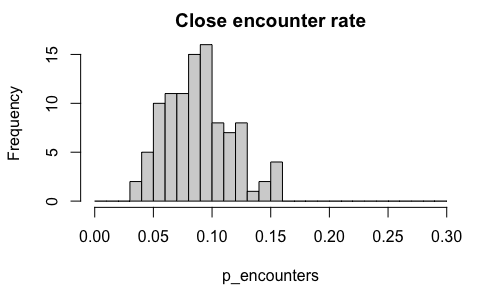

```r
par(mfrow=c(1,1), mar=c(4.2,4.2,2,1))
hist(p_encounters,
      breaks=seq(0,.3,by=.01),
      main='Close encounter rate')
```

Calculate statistics:

```r
# Mean encounter rate
p_encounters %>% mean %>% round(3)
```

```
#> [1] 0.094
```

```r
# SD encounter rate
p_encounters %>% sd %>% round(3)
```

```
#> [1] 0.028
```

```r
# 95% confidence interval of the mean
BootCI(p_encounters,FUN=mean)[2:3]
```

```
#>     lwr.ci     upr.ci
#> 0.08805415 0.09904435
```

```r
# 90% range of encounter rates
quantile(p_encounters,c(0.05,0.95))
```

```
#>   5%  95%
#> 0.05 0.15
```

## Impacts assessment

To incorporate this encounter rate into a shipping impacts assessment framework, we conduct the following stochastic routine. The `tankers` object tells us the total kilometers transited during the study window (July 1 - October 31):

```r
km <- summarize_grid(tanker)$km
km
```

```
#> [1] 12305
```

We can treat this number of kilometers as the number of potential co-occurrence opportunities during that timeframe. We pass that value to the `shipstrike` function `outcome()`, along with the following probabilities:

- `p_whale`: the probability of a whale occurring within a single square kilometer, which is whale density; we provide this as a truncated normal distribution based on the results from Keen et al. (2021);
- `p_encounter`: the close encounter probability distribution, which we prepared above;
- `p_surface`: the probability of the whale occurring within the near-surface ‘strike zone’ at the time of the close enocounter, which for our purposes here we treat as a single average value based on our review of the literature;
- `p_avoidance`: the probability of avoidance, which for our purposes here we treat as a single average value representing the best possible case based on our review of the literature;
- `p_lethality`: the probability of mortality in the event of collision, which we treat simply as a single average value drawn from the literature;

Here is a single run of the `outcome()` function:

```r
outcome(p_whale = truncnorm::rtruncnorm(10000, a=0, mean=0.015,sd=0.0031),
        p_encounter = p_encounters,
        p_surface = 0.62,
        p_avoidance = 0.66,
        p_lethality = 0.42,
        km = km,
        iterations = 1)
```

```
#>   cooccurrence encounter surface collision mortality
#> .          182        17      12         3         2
```

This function uses stochastic methods to predict the number of co-occurrence events, close encounters, surface-overlap events, collisions (in the event of failed avoidance), and mortalities. Since this is a stochastic prediction, if we run it again we will get slightly different predictions:

```r
outcome(p_whale = truncnorm::rtruncnorm(10000, a=0, mean=0.015,sd=0.0031),
        p_encounter = p_encounters,
        p_surface = 0.62,
        p_avoidance = 0.66,
        p_lethality = 0.42,
        km = km,
        iterations = 1)
```

```
#>   cooccurrence encounter surface collision mortality
#> .          169         8       4         3         2
```

A stochastic approach like this allows the uncertainty inherent to any of the parameters (in this specific example, for instance, we have built uncertainty into `p_whale` and `p_encounter`) to propagate into our outcome predictions. To do so, change the `iterations` argument for the function. Doing so will generate a posterior distribution of predictions; for this demo we will just use 1,000 iterations (the published paper uses 10,000):

```r
# Iteratively predict outcomes
results <- outcome(p_whale = truncnorm::rtruncnorm(10000, a=0,
                                                   mean=0.015,
                                                   sd=0.0031),
                   p_encounter = p_encounters,
                   p_surface = 0.62,
                   p_avoidance = 0.66,
                   p_lethality = 0.42,
                   km = km,
                   iterations = 1000,
                   verbose = FALSE)
```

View a histogram of the results, using a `shipstrike` function:

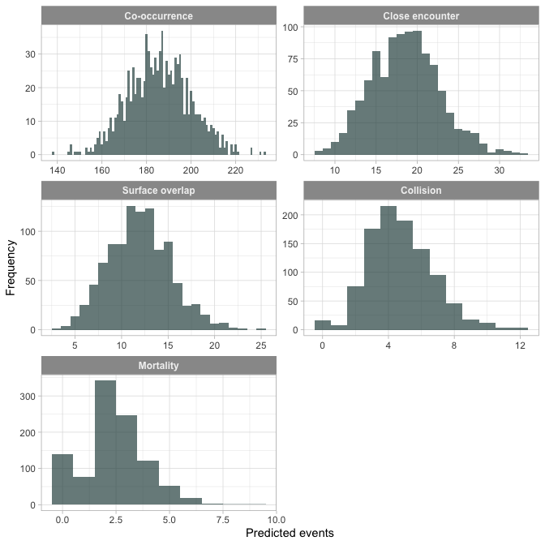

```r
outcome_histograms(results)
```

Create a summary table of the results, with another `shipstrike` function:

```r
outcome_table(results) %>% knitr::kable()
```

|  | impact | mean | median | sd | L90 | U90 | C80 | mean5 | mean10 |
| --- | --- | --- | --- | --- | --- | --- | --- | --- | --- |
| 5% | cooccurrence | 186 | 186 | 14 | 163 | 209 | 174 | 930 | 1860 |
| 5%1 | encounter | 19 | 19 | 4 | 12 | 26 | 15 | 95 | 190 |
| 5%2 | surface | 12 | 12 | 3 | 7 | 18 | 9 | 60 | 120 |
| 5%3 | collision | 5 | 5 | 2 | 2 | 8 | 3 | 25 | 50 |
| 5%4 | mortality | 2 | 2 | 1 | 0 | 5 | 1 | 10 | 20 |

The columns `mean` and `sd` provide the annual expectation for each kind of outcome event/impact. The `L90` and `U90` provide the 90% confidence interval (based on the 5% and 95% quantiles of the outcome distributions). The `mean5` and `mean10` provid the expected impact over the course of 5 and 10 years, respectively.

## Code used in publication

The following chunks of code show the code used to develop the 1000-iteration results used in our publication:

### 2018 Passenger ships

```r
passenger18 <- vgrid %>% dplyr::filter(tolower(type) == 'passenger ship')
params.ship <- summarize_grid(passenger18)$params.ship

iterations <- 1000
runs <- 100
par(mfrow=c(2,2))
p_encounters <- c()
for(i in 1:iterations){
  encounters <- encounter_simulator(params.ship = params.ship,
                        v.whale = v.whale,
                        l.whale = l.whale,
                        w.whale = w.whale,
                        delta.sd = delta.sd,
                        B = runs)
  encs <- encounter_tally(encounters)$total
  (p_encounter <- encs / runs)
  p_encounters <- c(p_encounters, p_encounter)
  #save(p_encounters, file='../results/2018_passenger.RData')
  message(i,' :: ',p_encounter)
}

#load('../results/2018_tanker.RData')

# Review results
par(mfrow=c(1,1), mar=c(4.2,4.2,2,1))
hist(p_encounters, breaks=seq(0,.3,by=.01), main='Close encounter rate')

# Summarize
p_encounters %>% mean %>% round(3)
p_encounters %>% sd %>% round(3)
BootCI(p_encounters,FUN=mean)[2:3]
quantile(p_encounters,c(0.05,0.95))
```

### 2018 Cargo ships

```r
cargo18 <- vgrid %>% dplyr::filter(tolower(type) == 'cargo ship')
params.ship <- summarize_grid(cargo18)$params.ship
params.ship

iterations <- 1000
runs <- 100
par(mfrow=c(2,2))
p_encounters <- c()
for(i in 1:iterations){
  encounters <- encounter_simulator(params.ship = params.ship,
                        v.whale = v.whale,
                        l.whale = l.whale,
                        w.whale = w.whale,
                        delta.sd = delta.sd,
                        B = runs)
  encs <- encounter_tally(encounters)$total
  (p_encounter <- encs / runs)
  p_encounters <- c(p_encounters, p_encounter)
  #save(p_encounters, file='../results/2018_cargo.RData')
  message(i,' :: ',p_encounter)
}

#load('../results/2018_cargo.RData')

# Review results
par(mfrow=c(1,1), mar=c(4.2,4.2,2,1))
hist(p_encounters, breaks=seq(0,.3,by=.01), main='Close encounter rate')

# Summarize
p_encounters %>% mean %>% round(3)
p_encounters %>% sd %>% round(3)
BootCI(p_encounters,FUN=mean)[2:3]
quantile(p_encounters,c(0.05,0.95))
```

### 2030 Tankers

```r
# 2030 Tanker ==================================================================
tanker30 <- vgrid_sim
params.ship <- summarize_grid(tanker30)$params.ship
params.ship

iterations <- 1000
runs <- 100
par(mfrow=c(2,2))
p_encounters <- c()
for(i in 1:iterations){
  encounters <- encounter_simulator(params.ship = params.ship,
                        v.whale = v.whale,
                        l.whale = l.whale,
                        w.whale = w.whale,
                        delta.sd = delta.sd,
                        B = runs)
  encs <- encounter_tally(encounters)$total
  (p_encounter <- encs / runs)
  p_encounters <- c(p_encounters, p_encounter)
  #save(p_encounters, file='../results/2030_tanker.RData')
  message(i,' :: ',p_encounter)
}

#load('../results/2030_tanker.RData')

# Review results
par(mfrow=c(1,1), mar=c(4.2,4.2,2,1))
hist(p_encounters, breaks=seq(0,.3,by=.01), main='Close encounter rate')

# Summarize
p_encounters %>% mean %>% round(3)
p_encounters %>% sd %>% round(3)
BootCI(p_encounters,FUN=mean)[2:3]
quantile(p_encounters,c(0.05,0.95))
```

### Comparing these results

Load the data:

```r
load('../results/2018_passenger.RData')
df1 <- data.frame(Type='2018 Passenger ships', p_encounters)
head(df1)
```

```
#>                   Type p_encounters
#> 1 2018 Passenger ships         0.03
#> 2 2018 Passenger ships         0.05
#> 3 2018 Passenger ships         0.05
#> 4 2018 Passenger ships         0.05
#> 5 2018 Passenger ships         0.10
#> 6 2018 Passenger ships         0.05
```

```r
load('../results/2018_cargo.RData')
df2 <- data.frame(Type='2018 Cargo ships', p_encounters)

load('../results/2030_tanker.RData')
df3 <- data.frame(Type='2030 Tankers', p_encounters)

results <- rbind(df1, df2, df3)
```

Summary table:

```r
results %>%
  group_by(Type) %>%
  summarize(ER_mean = round((100*mean(p_encounters)),1),
            ER_LCI = round((100*BootCI(p_encounters, FUN=mean)[2]),1),
            ER_UCI = round((100*BootCI(p_encounters, FUN=mean)[3]),1),
            Q90 = paste(round((100*quantile(p_encounters, c(0.05, 0.95))),1), collapse=' - '))
```

[output not shown]

Prepare function for iterative differencing:

```r
pval <- function(val1, val2, B=10000){
  vals1 <- sample(val1,size=B,replace=TRUE)
  vals2 <- sample(val2,size=B,replace=TRUE)
  diffs <- vals1 - vals2

  p1 <- length(which(diffs>0)) / length(diffs) # If significant = val 1 is larger than val2
  p2 <- length(which(diffs<0)) / length(diffs) # If significant = val 2 is larger than val1

  par(mar=c(4.2,4.2,3,1))
  hist(diffs,col="grey70",border="grey60",main="val1 - val2",xlab="Differences")
  abline(v=0,lty=3,col="steelblue")

  return(list(diffs=diffs,p1=p1,p2=p2))
}
```

Conduct statistical tests:

```r
pval(val1= results$p_encounters[results$Type == '2018 Passenger ships'],
     val2=results$p_encounters[results$Type == '2018 Cargo ships'])

pval(val1= results$p_encounters[results$Type == '2018 Cargo ships'],
     val2=results$p_encounters[results$Type == '2018 Passenger ships'])

pval(val1= results$p_encounters[results$Type == '2018 Cargo ships'],
     val2=results$p_encounters[results$Type == '2030 Tankers'])

pval(val1= results$p_encounters[results$Type == '2030 Tankers'],
     val2=results$p_encounters[results$Type == '2018 Passenger ships'])

pval(val1= results$p_encounters[results$Type == '2030 Tankers'],
     val2=results$p_encounters[results$Type == '2018 Cargo ships'])
```

Produce histogram plot:

```r
library(ggplot2)
ggplot(results,
       aes(x=p_encounters, fill=Type, color=Type)) +
  geom_density(alpha=.3) +
  xlab('Close enounter rate') +
  ylab('Probability density') +
  scale_fill_manual(values=c('darkblue','grey40','firebrick')) +
  scale_color_manual(values=c('darkblue','grey40','firebrick')) +
  theme_light()
```

[output not shown]

### Preparing a simplified impact assessment

#### 2018 Passenger ships

```r
# Get grid cells intersected
passenger18 <- vgrid %>% dplyr::filter(tolower(type) == 'passenger ship')
km <- summarize_grid(passenger18)$km

# Load p_encounters
load('../results/2018_passenger.RData')

# Iteratively predict outcomes
results <- outcome(p_whale = truncnorm::rtruncnorm(10000, a=0,
                                                   mean=0.015,
                                                   sd=0.0031),
                   p_encounter = p_encounters,
                   p_surface = 0.62,
                   p_avoidance = 0.66,
                   p_lethality = 0.42,
                   km = km,
                   iterations = 10000)

# Review as a table
outcome_table(results)

# Review as histogram
outcome_histograms(results)
```

#### 2018 Cargo ships

```r
# Get grid cells intersected
cargo18 <- vgrid %>% dplyr::filter(tolower(type) == 'cargo ship')
km <- summarize_grid(cargo18)$km

# Load p_encounters
load('../results/2018_cargo.Rdata')

# Iteratively predict outcomes
results <- outcome(p_whale = truncnorm::rtruncnorm(10000, a=0,
                                                   mean=0.015,
                                                   sd=0.0031),
                   p_encounter = p_encounters,
                   p_surface = 0.62,
                   p_avoidance = 0.66,
                   p_lethality = 0.42,
                   km = km,
                   iterations = 10000)

# Review as a table
outcome_table(results)

# Review as histogram
outcome_histograms(results)
```

#### 2030 Tankers

```r
km <- summarize_grid(tanker)$km

# Load p_encounters
load('../results/2030_tanker.Rdata')

# Iteratively predict outcomes
results <- outcome(p_whale = truncnorm::rtruncnorm(10000, a=0,
                                                   mean=0.015,
                                                   sd=0.0031),
                   p_encounter = p_encounters,
                   p_surface = 0.62,
                   p_avoidance = 0.66,
                   p_lethality = 0.42,
                   km = km,
                   iterations = 10000)

# Review as a table
outcome_table(results)

# Review as histogram
outcome_histograms(results)
```

### Sensitivity analysis

Using passenger ship data from 2018:

```r
passenger18 <- vgrid %>% dplyr::filter(tolower(type) == 'passenger ship')
head(passenger18)
params.ship <- summarize_grid(passenger18)$params.ship
head(params.ship)
```

#### Track variability

```r
delta.sds = c(0,10,20,30,40,50,60,70)
vars <- delta.sds

iterations <- 100
runs <- 100
mrs <- data.frame() # details
par(mfrow=c(2,2))
varb <- 8
for(varb in 1:length(vars)){
  vari <- vars[varb] ; vari

  for(i in 1:iterations){
    encounters <- encounter_simulator(params.ship = params.ship,
                        v.whale = v.whale,
                        l.whale = l.whale,
                        w.whale = w.whale,
                        delta.sd = vari,
                        B = runs)
  encs <- encounter_tally(encounters)$total
  (p_encounter <- encs / runs)
  mrsi <- data.frame(vari, p_encounter)
  mrs <- rbind(mrs, mrsi)
  save(mrs, file='../results/sim-deltasd.RData')
  message(Sys.time()," | delta.sd | ",vari," deg/min | iteration ",i," | rate = ",p_encounter)
  }
}
```

#### Whale length

```r
l.whales = c(9,12,15,18,21,24,27,30)
vars <- l.whales

iterations <- 100
runs <- 100
mrs <- data.frame()
par(mfrow=c(2,2))
varb <- 5
for(varb in 1:length(vars)){
  vari <- vars[varb] ; vari

  for(i in 1:iterations){
    encounters <- encounter_simulator(params.ship = params.ship,
                        v.whale = v.whale,
                        l.whale = vari,
                        w.whale = w.whale,
                        delta.sd = delta.sd,
                        B = runs)
  encs <- encounter_tally(encounters)$total
  (p_encounter <- encs / runs)
  mrsi <- data.frame(vari, p_encounter)
  mrs <- rbind(mrs, mrsi)
  save(mrs, file='../results/sim-lwhale.RData')
  message(Sys.time()," | l.whale | ",vari," m | iteration ",i," | rate = ",p_encounter)
  }
}
```

#### Whale speed

```r
v.whales <- c(0.5,1,1.5,2,2.5,3,3.5,4) ; v.whales
vars <- v.whales

iterations <- 100
runs <- 100
mrs <- data.frame()
par(mfrow=c(2,2))
varb <- 8
for(varb in 1:length(vars)){
  vari <- vars[varb] ; vari

  for(i in 1:iterations){
    encounters <- encounter_simulator(params.ship = params.ship,
                        v.whale = vari,
                        l.whale = l.whale,
                        w.whale = w.whale,
                        delta.sd = delta.sd,
                        B = runs)
  encs <- encounter_tally(encounters)$total
  (p_encounter <- encs / runs)
  mrsi <- data.frame(vari, p_encounter)
  mrs <- rbind(mrs, mrsi)
  #save(mrs, file='../results/sim-vwhale.RData')
  message(Sys.time()," | v.whale | ",vari," m/s | iteration ",i," | rate = ",p_encounter)
  }
}
```

#### Ship speed

```r
v.ships <- c(4,8,12,16,20,24,28,32)
vars <- v.ships

iterations <- 100
runs <- 100
mrs <- data.frame()
par(mfrow=c(2,2))
varb <- 5
for(varb in 1:length(vars)){
  vari <- vars[varb] ; vari
  parami <- params.ship
  parami$v.ship <- vari

  for(i in 1:iterations){
    encounters <- encounter_simulator(params.ship = parami,
                        v.whale = v.whale,
                        l.whale = l.whale,
                        w.whale = w.whale,
                        delta.sd = delta.sd,
                        B = runs)
  encs <- encounter_tally(encounters)$total
  (p_encounter <- encs / runs)
  mrsi <- data.frame(vari, p_encounter)
  mrs <- rbind(mrs, mrsi)
  save(mrs, file='../results/sim-vship.RData')
  message(Sys.time()," | v.ship | ",vari," kn | iteration ",i," | rate = ",p_encounter)
  }
}
```

#### Ship length

```r
l.ships <- c(10,20,50,100,150,200,250,300,350)
vars <- l.ships

iterations <- 100
runs <- 100
mrs <- data.frame()
par(mfrow=c(2,2))
varb <- 9
for(varb in 1:length(vars)){
  vari <- vars[varb] ; vari
  parami <- params.ship
  parami$l.ship <- vari
  parami$w.ship <- vari * 0.125

  for(i in 1:iterations){
    encounters <- encounter_simulator(params.ship = parami,
                        v.whale = v.whale,
                        l.whale = l.whale,
                        w.whale = w.whale,
                        delta.sd = delta.sd,
                        B = runs)
  encs <- encounter_tally(encounters)$total
  (p_encounter <- encs / runs)
  mrsi <- data.frame(vari, p_encounter)
  mrs <- rbind(mrs, mrsi)
  save(mrs, file='../results/sim-lship.RData')
  message(Sys.time()," | l.ship | ",vari," m | iteration ",i," | rate = ",p_encounter)
  }
}
```

#### Summarize sensitivity analysis results

Stage a helper function:

```r
sensitivity_summary <- function(mrs){
mrsumm <-
  mrs %>%
  group_by(vari) %>%
  summarize(pe_mean = mean(p_encounter)*100,
            pe_L90 = quantile(p_encounter, 0.05)*100,
            pe_U90 = quantile(p_encounter, 0.95)*100) %>%
  mutate(pe_diff = pe_mean - lag(pe_mean))

mrsumm

(change_per_level <- paste0(round((mean(mrsumm$pe_diff, na.rm=TRUE)), 2),'%'))

plm <- lm(pe_mean ~ vari, data=mrsumm)
(plmsumm <- summary(plm))
(lm_pval <- plmsumm$coefficients[2,4] %>% round(3))

minmax_pval <- pval(val1=mrs$p_encounter[mrs$vari == min(mrs$vari)],
                    val2=mrs$p_encounter[mrs$vari == max(mrs$vari)])$p1

mrsumm <-
  mrsumm %>%
  mutate(pe_mean = paste0(round(pe_mean, 2),'%'),
            pe_L90 = paste0(round(pe_L90,2),'%'),
            pe_U90 = paste0(round(pe_U90,2),'%')) %>%
  select(vari:pe_U90)

print(mrsumm %>% select(vari:pe_U90))
message('Percent change per level = ',change_per_level)
message('Min Max p value = ', minmax_pval)
message('Regression p value = ', lm_pval)
}
```

Plot and print statistics:

```r
load('../results/sim-lship.RData')
sensitivity_summary(mrs)
(mrsum <- mrs %>% group_by(vari) %>%
    summarize(vmean = mean(p_encounter), lci = quantile(p_encounter, .05), uci = quantile(p_encounter, .95)))
plship <- ggplot(mrs, aes(x=factor(vari), y=p_encounter)) +
  geom_jitter(width=.1, height=.002, alpha=.2, size=.8) + ylim(0,.2) +
  geom_errorbar(data=mrsum, mapping=aes(x=factor(vari), ymin=lci, ymax=uci), width=.2, size=1, color='firebrick') +
  geom_point(data=mrsum, mapping=aes(x=factor(vari), y=vmean), size=3, color='firebrick') +
  ylab('Close Encounter Rate') + xlab(NULL) + theme_light() + labs(title='Vessel length (m)')
#plship

load('../results/sim-vship.RData')
sensitivity_summary(mrs)
(mrsum <- mrs %>% group_by(vari) %>%
    summarize(vmean = mean(p_encounter), lci = quantile(p_encounter, .05), uci = quantile(p_encounter, .95)))
pvship <- ggplot(mrs, aes(x=factor(vari), y=p_encounter)) +
  geom_jitter(width=.1, height=.002, alpha=.2, size=.8) + ylim(0,.2) +
  geom_errorbar(data=mrsum, mapping=aes(x=factor(vari), ymin=lci, ymax=uci), width=.2, size=1, color='firebrick') +
  geom_point(data=mrsum, mapping=aes(x=factor(vari), y=vmean), size=3, color='firebrick') +
  ylab('Close Encounter Rate') + xlab(NULL) + theme_light() + labs(title='Vessel speed (kn)')
#pvship

load('../results/sim-vwhale.RData')
sensitivity_summary(mrs)
(mrsum <- mrs %>% group_by(vari) %>%
    summarize(vmean = mean(p_encounter), lci = quantile(p_encounter, .05), uci = quantile(p_encounter, .95)))
pvwhale <- ggplot(mrs, aes(x=factor(vari), y=p_encounter)) +
  geom_jitter(width=.1, height=.002, alpha=.2, size=.8) + ylim(0,.2) +
  geom_errorbar(data=mrsum, mapping=aes(x=factor(vari), ymin=lci, ymax=uci), width=.2, size=1, color='firebrick') +
  geom_point(data=mrsum, mapping=aes(x=factor(vari), y=vmean), size=3, color='firebrick') +
  ylab('Close Encounter Rate') + xlab(NULL) + theme_light() + labs(title='Whale speed (m/s)')
#pvwhale

load('../results/sim-lwhale.RData')
sensitivity_summary(mrs)
(mrsum <- mrs %>% group_by(vari) %>%
    summarize(vmean = mean(p_encounter), lci = quantile(p_encounter, .05), uci = quantile(p_encounter, .95)))
plwhale <- ggplot(mrs, aes(x=factor(vari), y=p_encounter)) +
  geom_jitter(width=.1, height=.002, alpha=.2, size=.8) + ylim(0,.2) +
  geom_errorbar(data=mrsum, mapping=aes(x=factor(vari), ymin=lci, ymax=uci), width=.2, size=1, color='firebrick') +
  geom_point(data=mrsum, mapping=aes(x=factor(vari), y=vmean), size=3, color='firebrick') +
  ylab('Close Encounter Rate') + xlab(NULL) + theme_light() + labs(title='Whale length (m)')
#plwhale

load('../results/sim-deltasd.RData')
sensitivity_summary(mrs)
(mrsum <- mrs %>% group_by(vari) %>%
    summarize(vmean = mean(p_encounter), lci = quantile(p_encounter, .05), uci = quantile(p_encounter, .95)))
pdeltasd <- ggplot(mrs, aes(x=factor(vari), y=p_encounter)) +
  geom_jitter(width=.1, height=.002, alpha=.2, size=.8) + ylim(0,.2) +
  geom_errorbar(data=mrsum, mapping=aes(x=factor(vari), ymin=lci, ymax=uci), width=.2, size=1, color='firebrick') +
  geom_point(data=mrsum, mapping=aes(x=factor(vari), y=vmean), size=3, color='firebrick') +
  ylab('Close Encounter Rate') + xlab(NULL) + theme_light() + labs(title='Whale directivity (SD deg / min)')
#pdeltasd

ggarrange(plship, pvship, pvwhale, plwhale, pdeltasd, nrow=2, ncol=3, labels='auto')
```